# Instructions

- Some parts of the code are already done for you
- You need to execute all the cells
- You need to add the code where ever you see `"#### Add your code here ####"`
- Marks are mentioned along with the cells

# Face Mask Segmentation

Task is to predict the boundaries(mask) around the face in a given image.

## Dataset

### Mount Google drive if you are using google colab

- We recommend using Google Colab as you can face memory issues and longer runtimes while running on local

```python
from google.colab import drive
drive.mount('/content/drive')
```

```
Go to this URL in a browser: https://accounts.google.com/o/oauth2/auth?client_id=947318989803-6bn6qk8qdgf4n4g3pfee6491hc0brc4i.apps.googleusercontent.com&redirect_uri=urn%3aietf%3awg%3aoauth%3a2.0%3aoob&response_type=code&scope=email%20https%3a%2f%2fwww.googleapis.com%2fauth%2fdocs.test%20https%3a%2…

Enter your authorization code:
··········
```

```python
%tensorflow_version 2.x
import tensorflow
tensorflow.__version__
```

```
'2.2.0'
```

```python
# Initialize the random number generator
import random
random.seed(0)

# Ignore the warnings
import warnings
warnings.filterwarnings("ignore")
```

### Change current working directory to project folder (1 mark)

```python
import os
path = '/content/drive/My Drive/comp_vision_proj/images.npy'
test_images_path = '/content/drive/My Drive/comp_vision_proj/test/'
```

### Load the "images.npy" file (2 marks)

- This file contains images with details of bounding boxes

```python
#loading numpy
import numpy as np
data = np.load(path, allow_pickle=True)
```

```python
print('shape of the data is ', data.shape)
```

```
shape of the data is  (409, 2)
```

### Check one sample from the loaded "images.npy" file (2 marks)

Hint - print data[10][1]

```python
print('First image in array format', data[0][0])
```

[output not shown]

```python
print('The second column in the 10 th data point  is ')
print(data[10][1])
```

```
The second column in the 10 th data point  is
[{'label': ['Face'], 'notes': '', 'points': [{'x': 0.48, 'y': 0.10385756676557864}, {'x': 0.7716666666666666, 'y': 0.6795252225519288}], 'imageWidth': 600, 'imageHeight': 337}]
```

### Set image dimensions (2 marks)

- Initialize image height, image width with value: 224

```python
IMAGE_WIDTH = 224
IMAGE_HEIGHT = 224
```

### Create features and labels

- Here feature is the image
- The label is the mask
- Images will be stored in "X_train" array
- Masks will be stored in "masks" array

```python
'''
Lets use the first 400 data points to train and the remaining ones to validation set
'''

data_train = data[0:400]
data_val = data[401:]
```

```python
#mask create
import cv2
from tensorflow.keras.applications.mobilenet import preprocess_input

masks = np.zeros((int(data_train.shape[0]), IMAGE_HEIGHT, IMAGE_WIDTH))
X_train = np.zeros((int(data_train.shape[0]), IMAGE_HEIGHT, IMAGE_WIDTH, 3))
for index in range(data_train.shape[0]):
    img = data_train[index][0]
    img = cv2.resize(img, dsize=(IMAGE_HEIGHT, IMAGE_WIDTH), interpolation=cv2.INTER_CUBIC)
    try:
      img = img[:, :, :3]
    except:
      continue
    X_train[index] = preprocess_input(np.array(img, dtype=np.float32))
    for i in data[index][1]:
        x1 = int(i["points"][0]['x'] * IMAGE_WIDTH)
        x2 = int(i["points"][1]['x'] * IMAGE_WIDTH)
        y1 = int(i["points"][0]['y'] * IMAGE_HEIGHT)
        y2 = int(i["points"][1]['y'] * IMAGE_HEIGHT)
        masks[index][y1:y2, x1:x2] = 1
```

```python
#val masks create
masks_val = np.zeros((int(data_val.shape[0]), IMAGE_HEIGHT, IMAGE_WIDTH))
X_val = np.zeros((int(data_val.shape[0]), IMAGE_HEIGHT, IMAGE_WIDTH, 3))
for index in range(data_val.shape[0]):
    img = data_val[index][0]
    img = cv2.resize(img, dsize=(IMAGE_HEIGHT, IMAGE_WIDTH), interpolation=cv2.INTER_CUBIC)
    try:
      img = img[:, :, :3]
    except:
      continue
    X_val[index] = preprocess_input(np.array(img, dtype=np.float32))
    for i in data[index][1]:
        x1 = int(i["points"][0]['x'] * IMAGE_WIDTH)
        x2 = int(i["points"][1]['x'] * IMAGE_WIDTH)
        y1 = int(i["points"][0]['y'] * IMAGE_HEIGHT)
        y2 = int(i["points"][1]['y'] * IMAGE_HEIGHT)
        masks_val[index][y1:y2, x1:x2] = 1
```

### Print the shape of X_train and mask array (2 marks)

```python
print("Shape of the X train data is:",X_train.shape)
```

```
Shape of the X train data is: (400, 224, 224, 3)
```

```python
print("Shape of the X train data is:",masks.shape)
```

```
Shape of the X train data is: (400, 224, 224)
```

### Print a sample image and image array

```
Clipping input data to the valid range for imshow with RGB data ([0..1] for floats or [0..255] for integers).
```

```
index of the image: 26
```

[figure not shown]

[output not shown]

```python
from matplotlib import pyplot
n = 26
print('index of the image:',n)
pyplot.imshow(X_train[n])
pyplot.show()
print('Array of 26th train:', X_train[26])
```

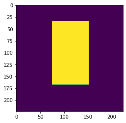

```python
pyplot.imshow(masks[n])
```

## Create the model (10 marks)

- Add MobileNet as model with below parameter values
  - input_shape: IMAGE_HEIGHT, IMAGE_WIDTH, 3
  - include_top: False
  - alpha: 1.0
  - weights: "imagenet"
- Add UNET architecture layers
  - This is the trickiest part of the project, you need to research and implement it correctly

```python
from tensorflow.keras.applications.mobilenet import MobileNet
from tensorflow.keras.layers import Concatenate, UpSampling2D, Conv2D, Reshape
from tensorflow.keras.models import Model


ALPHA = 1 # Width hyper parameter for MobileNet (0.25, 0.5, 0.75, 1.0). Higher width means more accurate but slower

IMAGE_HEIGHT = 224
IMAGE_WIDTH = 224

HEIGHT_CELLS = 28
WIDTH_CELLS = 28

def create_model(trainable=True):
    model = MobileNet(input_shape=(IMAGE_HEIGHT, IMAGE_WIDTH, 3), include_top=False, alpha=ALPHA, weights="imagenet")
    for layer in model.layers:
      layer.trainable = trainable


    block = model.get_layer("conv_pw_1_relu").output
    block1 = model.get_layer("conv_pw_3_relu").output
    block2 = model.get_layer("conv_pw_5_relu").output
    block3 = model.get_layer("conv_pw_11_relu").output
    block4 = model.get_layer("conv_pw_13_relu").output

    x = Concatenate()([UpSampling2D()(block4), block3])
    x = Concatenate()([UpSampling2D()(x), block2])
    x = Concatenate()([UpSampling2D()(x), block1])
    x = Concatenate()([UpSampling2D()(x), block])
    x = UpSampling2D()(x)
    x = Conv2D(1, kernel_size=1, activation="sigmoid")(x)

    x = Reshape((IMAGE_HEIGHT, IMAGE_HEIGHT))(x)

    return Model(inputs=model.input, outputs=x)
```

### Call the create_model function

```python
# Give trainable=False as argument, if you want to freeze lower layers for fast training (but low accuracy)
model = create_model(trainable = False)

# Print summary
model.summary()
```

```
Downloading data from https://storage.googleapis.com/tensorflow/keras-applications/mobilenet/mobilenet_1_0_224_tf_no_top.h5
Model: "model"
__________________________________________________________________________________________________
Layer (type)                    Output Shape         Param #     Connected to
==================================================================================================
input_1 (InputLayer)            [(None, 224, 224, 3) 0
__________________________________________________________________________________________________
conv1_pad (ZeroPadding2D)       (None, 225, 225, 3)  0           input_1[0][0]
__________________________________________________________________________________________________
conv1 (Conv2D)                  (None, 112, 112, 32) 864         conv1_pad[0][0]
__________________________________________________________________________________________________
conv1_bn (BatchNormalization)   (None, 112, 112, 32) 128         conv1[0][0]
__________________________________________________________________________________________________
conv1_relu (ReLU)               (None, 112, 112, 32) 0           conv1_bn[0][0]
__________________________________________________________________________________________________
conv_dw_1 (DepthwiseConv2D)     (None, 112, 112, 32) 288         conv1_relu[0][0]
__________________________________________________________________________________________________
conv_dw_1_bn (BatchNormalizatio (None, 112, 112, 32) 128         conv_dw_1[0][0]
__________________________________________________________________________________________________
conv_dw_1_relu (ReLU)           (None, 112, 112, 32) 0           conv_dw_1_bn[0][0]
__________________________________________________________________________________________________
conv_pw_1 (Conv2D)              (None, 112, 112, 64) 2048        conv_dw_1_relu[0][0]
__________________________________________________________________________________________________
conv_pw_1_bn (BatchNormalizatio (None, 112, 112, 64) 256         conv_pw_1[0][0]
__________________________________________________________________________________________________
conv_pw_1_relu (ReLU)           (None, 112, 112, 64) 0           conv_pw_1_bn[0][0]
__________________________________________________________________________________________________
conv_pad_2 (ZeroPadding2D)      (None, 113, 113, 64) 0           conv_pw_1_relu[0][0]
__________________________________________________________________________________________________
conv_dw_2 (DepthwiseConv2D)     (None, 56, 56, 64)   576         conv_pad_2[0][0]
__________________________________________________________________________________________________
conv_dw_2_bn (BatchNormalizatio (None, 56, 56, 64)   256         conv_dw_2[0][0]
__________________________________________________________________________________________________
conv_dw_2_relu (ReLU)           (None, 56, 56, 64)   0           conv_dw_2_bn[0][0]
__________________________________________________________________________________________________
conv_pw_2 (Conv2D)              (None, 56, 56, 128)  8192        conv_dw_2_relu[0][0]
__________________________________________________________________________________________________
conv_pw_2_bn (BatchNormalizatio (None, 56, 56, 128)  512         conv_pw_2[0][0]
__________________________________________________________________________________________________
conv_pw_2_relu (ReLU)           (None, 56, 56, 128)  0           conv_pw_2_bn[0][0]
```

[output cut: 154 more lines]

```
up_sampling2d_3 (UpSampling2D)  (None, 112, 112, 192 0           concatenate_2[0][0]
__________________________________________________________________________________________________
concatenate_3 (Concatenate)     (None, 112, 112, 198 0           up_sampling2d_3[0][0]
                                                                 conv_pw_1_relu[0][0]
__________________________________________________________________________________________________
up_sampling2d_4 (UpSampling2D)  (None, 224, 224, 198 0           concatenate_3[0][0]
__________________________________________________________________________________________________
conv2d (Conv2D)                 (None, 224, 224, 1)  1985        up_sampling2d_4[0][0]
__________________________________________________________________________________________________
reshape (Reshape)               (None, 224, 224)     0           conv2d[0][0]
==================================================================================================
Total params: 3,230,849
Trainable params: 1,985
Non-trainable params: 3,228,864
__________________________________________________________________________________________________
```

### Define dice coefficient function (10 marks)

- Create a function to calculate dice coefficient

```python
def dice_coefficient(y_true, y_pred):
    numerator = 2 * tensorflow.reduce_sum(y_true * y_pred)
    denominator = tensorflow.reduce_sum(y_true + y_pred)

    return numerator / (denominator + tensorflow.keras.backend.epsilon())
```

### Define loss

```python
from tensorflow.keras.losses import binary_crossentropy
from tensorflow.keras.backend import log, epsilon
import tensorflow as tf

def loss(y_true, y_pred):
    return binary_crossentropy(y_true, y_pred) - log(dice_coefficient(y_true, y_pred) + epsilon())
```

### Compile the model (3 marks)

- Complie the model using below parameters
  - loss: use the loss function defined above
  - optimizers: use Adam optimizer
  - metrics: use dice_coefficient function defined above

```python
# compile model
from tensorflow.keras.optimizers import Adam
optimizer = Adam(lr=5e-6, beta_1=0.9, beta_2=0.999, epsilon=None, decay=0.0, amsgrad=False)
model.compile(optimizer = optimizer, loss=loss, metrics=[dice_coefficient])
```

### Define checkpoint and earlystopping

```python
from tensorflow.keras.callbacks import ModelCheckpoint, EarlyStopping, ReduceLROnPlateau
my_calls = [ModelCheckpoint("model-{loss:.2f}.h5", monitor="val_loss", verbose=1, save_best_only=True,
                             save_weights_only=True, mode="auto", period=1),
            EarlyStopping(monitor="val_loss", patience=6, mode="auto"),
            ReduceLROnPlateau(monitor="val_loss", factor=0.2, patience=5, min_lr=5e-4, verbose=1, mode="auto")]
```

```
WARNING:tensorflow:`period` argument is deprecated. Please use `save_freq` to specify the frequency in number of batches seen.
```

### Fit the model (3 marks)

- Fit the model using below parameters
  - epochs: you can decide
  - batch_size: 1
  - callbacks: checkpoint, reduce_lr, stop

```python
#### Add your code here ####
history = model.fit(X_train, masks, validation_data = (X_val, masks_val), epochs=50, batch_size=1, verbose=1,callbacks = my_calls)
```

```
Epoch 00001: val_loss improved from inf to 3.64728, saving model to model-3.48.h5
Epoch 00002: val_loss improved from 3.64728 to 3.38842, saving model to model-2.94.h5
Epoch 00003: val_loss improved from 3.38842 to 3.26719, saving model to model-2.71.h5
Epoch 00004: val_loss improved from 3.26719 to 3.17899, saving model to model-2.54.h5
Epoch 00005: val_loss improved from 3.17899 to 3.10316, saving model to model-2.40.h5
Epoch 00006: val_loss improved from 3.10316 to 3.03769, saving model to model-2.27.h5
Epoch 00007: val_loss improved from 3.03769 to 2.97664, saving model to model-2.15.h5
Epoch 00008: val_loss improved from 2.97664 to 2.92377, saving model to model-2.04.h5
Epoch 00009: val_loss improved from 2.92377 to 2.87854, saving model to model-1.95.h5
Epoch 00010: val_loss improved from 2.87854 to 2.83928, saving model to model-1.87.h5
Epoch 00011: val_loss improved from 2.83928 to 2.80372, saving model to model-1.80.h5
Epoch 00012: val_loss improved from 2.80372 to 2.78246, saving model to model-1.73.h5
Epoch 00013: val_loss improved from 2.78246 to 2.74581, saving model to model-1.67.h5
Epoch 00014: val_loss improved from 2.74581 to 2.72582, saving model to model-1.62.h5
Epoch 00015: val_loss improved from 2.72582 to 2.70387, saving model to model-1.58.h5
Epoch 00016: val_loss improved from 2.70387 to 2.68090, saving model to model-1.53.h5
Epoch 00017: val_loss improved from 2.68090 to 2.66930, saving model to model-1.50.h5
Epoch 00018: val_loss improved from 2.66930 to 2.65369, saving model to model-1.46.h5
Epoch 00019: val_loss improved from 2.65369 to 2.64482, saving model to model-1.43.h5
Epoch 00020: val_loss improved from 2.64482 to 2.62677, saving model to model-1.40.h5
Epoch 00021: val_loss improved from 2.62677 to 2.62637, saving model to model-1.37.h5
Epoch 00022: val_loss improved from 2.62637 to 2.61287, saving model to model-1.35.h5
Epoch 00023: val_loss improved from 2.61287 to 2.60759, saving model to model-1.33.h5
Epoch 00024: val_loss improved from 2.60759 to 2.60631, saving model to model-1.30.h5
Epoch 00025: val_loss improved from 2.60631 to 2.60023, saving model to model-1.28.h5
Epoch 00026: val_loss improved from 2.60023 to 2.59141, saving model to model-1.27.h5
Epoch 00027: val_loss improved from 2.59141 to 2.58807, saving model to model-1.25.h5
Epoch 00028: val_loss improved from 2.58807 to 2.58202, saving model to model-1.23.h5
Epoch 00029: val_loss did not improve from 2.58202
Epoch 00030: val_loss did not improve from 2.58202
Epoch 00031: val_loss improved from 2.58202 to 2.57909, saving model to model-1.19.h5
Epoch 00032: val_loss improved from 2.57909 to 2.57668, saving model to model-1.18.h5
Epoch 00033: val_loss improved from 2.57668 to 2.56718, saving model to model-1.17.h5
Epoch 00034: val_loss did not improve from 2.56718
Epoch 00035: val_loss did not improve from 2.56718
Epoch 00036: val_loss did not improve from 2.56718
Epoch 00037: val_loss improved from 2.56718 to 2.56709, saving model to model-1.13.h5
Epoch 00038: val_loss did not improve from 2.56709
Epoch 00039: val_loss did not improve from 2.56709
Epoch 00040: val_loss did not improve from 2.56709
Epoch 00041: val_loss did not improve from 2.56709
Epoch 00042: val_loss did not improve from 2.56709
Epoch 00043: val_loss improved from 2.56709 to 2.56574, saving model to model-1.08.h5
Epoch 00044: val_loss did not improve from 2.56574
Epoch 00045: val_loss did not improve from 2.56574
Epoch 00046: val_loss did not improve from 2.56574
Epoch 00047: val_loss did not improve from 2.56574
Epoch 00048: val_loss did not improve from 2.56574
Epoch 00049: val_loss did not improve from 2.56574
```

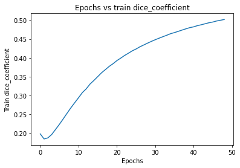

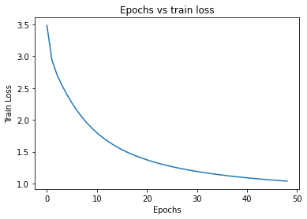

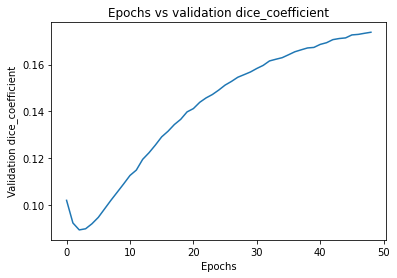

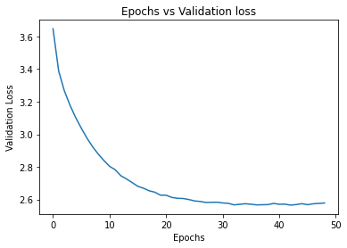

```python
from matplotlib import pyplot
# plot metrics
pyplot.plot(history.history['dice_coefficient'])
pyplot.title('Epochs vs train dice_coefficient')
pyplot.xlabel('Epochs')
pyplot.ylabel('Train dice_coefficient')
pyplot.show()

# plot metrics
pyplot.plot(history.history['loss'])
pyplot.title('Epochs vs train loss')
pyplot.xlabel('Epochs')
pyplot.ylabel('Train Loss')
pyplot.show()

# plot metrics
pyplot.plot(history.history['val_dice_coefficient'])
pyplot.title('Epochs vs validation dice_coefficient')
pyplot.xlabel('Epochs')
pyplot.ylabel('Validation dice_coefficient')
pyplot.show()

# plot metrics
pyplot.plot(history.history['val_loss'])
pyplot.title('Epochs vs Validation loss')
pyplot.xlabel('Epochs')
pyplot.ylabel('Validation Loss')
pyplot.show()
```

```python
results = model.evaluate(X_val, masks_val, verbose=1)
print("Val Dice Coeff:",results[1])
print("Val Loss:",results[0])
```

```
Val Dice Coeff: 0.18440312147140503
Val Loss: 2.165480375289917
```

### Get the predicted mask for a sample image (5 marks)

```python
#the below code is helpful to get all the test images names so that we can test them with our model

import os
#test_images_path is declared in the beginning of the notebook to avoid confusion
folder = os.fsencode(test_images_path)
filenames = []

for file in os.listdir(folder):
    filename = os.fsdecode(file)
    if filename.endswith( ('.jpg', '.jfij') ): # whatever file types you're using...
        filenames.append(filename)

filenames.sort()
```

```
original image
```

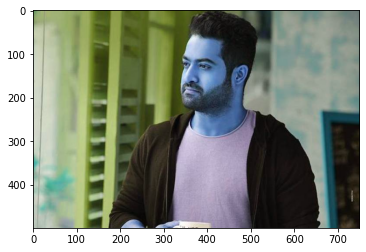

```
mask
```

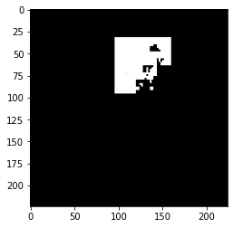

```
original image
```

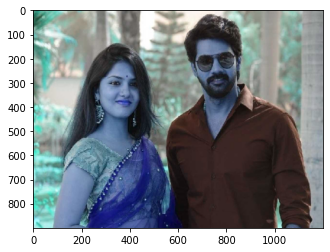

```
mask
```

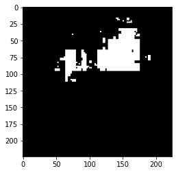

```
original image
```

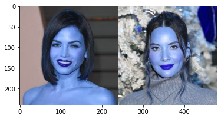

```
mask
```

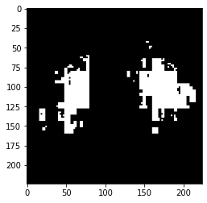

```
original image
```

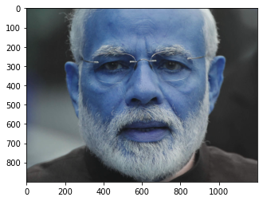

```
mask
```

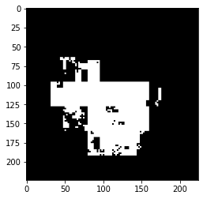

```python
import matplotlib.pyplot as plt
for filenam in filenames:
  print('*' * 50)
  filename = test_images_path + filenam
  unscaled = cv2.imread(filename)
  image = cv2.resize(unscaled, (IMAGE_WIDTH, IMAGE_HEIGHT))
  feat_scaled = preprocess_input(np.array(image, dtype=np.float32))

  pred_mask = cv2.resize(1.0*(model.predict(x=np.array([feat_scaled]))[0] > 0.5), (IMAGE_WIDTH,IMAGE_HEIGHT))

  image2 = image
  image2[:,:,0] = pred_mask*image[:,:,0]
  image2[:,:,1] = pred_mask*image[:,:,1]
  image2[:,:,2] = pred_mask*image[:,:,2]

  out_image = image2
  for i in range(224):
    for j in range(224):
      for k in range(3):
        if out_image[i][j][k]>0:
          out_image[i][j][k] = 255
  print('original image')
  plt.imshow(unscaled)
  plt.show()
  print('mask')
  plt.imshow(out_image)
  plt.show()
```

### Impose the mask on the image (5 marks)

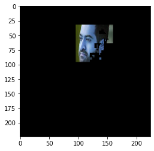

[figure not shown]

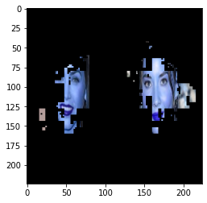

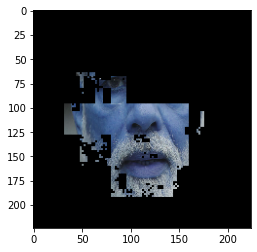

```python
import matplotlib.pyplot as plt
for filenam in filenames:
  print('*' * 50)
  filename = test_images_path + filenam
  unscaled = cv2.imread(filename)
  image = cv2.resize(unscaled, (IMAGE_WIDTH, IMAGE_HEIGHT))
  feat_scaled = preprocess_input(np.array(image, dtype=np.float32))

  pred_mask = cv2.resize(1.0*(model.predict(x=np.array([feat_scaled]))[0] > 0.5), (IMAGE_WIDTH,IMAGE_HEIGHT))

  image2 = image
  image2[:,:,0] = pred_mask*image[:,:,0]
  image2[:,:,1] = pred_mask*image[:,:,1]
  image2[:,:,2] = pred_mask*image[:,:,2]

  out_image = image2
  plt.imshow(out_image)
  plt.show()
  print('*'*50)
```

# Another implementation of Dice coefficient

```python
# Give trainable=False as argument, if you want to freeze lower layers for fast training (but low accuracy)
model2 = create_model(trainable = False)

# Print summary
model2.summary()
```

```
Model: "model_1"
__________________________________________________________________________________________________
Layer (type)                    Output Shape         Param #     Connected to
==================================================================================================
input_2 (InputLayer)            [(None, 224, 224, 3) 0
__________________________________________________________________________________________________
conv1_pad (ZeroPadding2D)       (None, 225, 225, 3)  0           input_2[0][0]
__________________________________________________________________________________________________
conv1 (Conv2D)                  (None, 112, 112, 32) 864         conv1_pad[0][0]
__________________________________________________________________________________________________
conv1_bn (BatchNormalization)   (None, 112, 112, 32) 128         conv1[0][0]
__________________________________________________________________________________________________
conv1_relu (ReLU)               (None, 112, 112, 32) 0           conv1_bn[0][0]
__________________________________________________________________________________________________
conv_dw_1 (DepthwiseConv2D)     (None, 112, 112, 32) 288         conv1_relu[0][0]
__________________________________________________________________________________________________
conv_dw_1_bn (BatchNormalizatio (None, 112, 112, 32) 128         conv_dw_1[0][0]
__________________________________________________________________________________________________
conv_dw_1_relu (ReLU)           (None, 112, 112, 32) 0           conv_dw_1_bn[0][0]
__________________________________________________________________________________________________
conv_pw_1 (Conv2D)              (None, 112, 112, 64) 2048        conv_dw_1_relu[0][0]
__________________________________________________________________________________________________
conv_pw_1_bn (BatchNormalizatio (None, 112, 112, 64) 256         conv_pw_1[0][0]
__________________________________________________________________________________________________
conv_pw_1_relu (ReLU)           (None, 112, 112, 64) 0           conv_pw_1_bn[0][0]
__________________________________________________________________________________________________
conv_pad_2 (ZeroPadding2D)      (None, 113, 113, 64) 0           conv_pw_1_relu[0][0]
__________________________________________________________________________________________________
conv_dw_2 (DepthwiseConv2D)     (None, 56, 56, 64)   576         conv_pad_2[0][0]
__________________________________________________________________________________________________
conv_dw_2_bn (BatchNormalizatio (None, 56, 56, 64)   256         conv_dw_2[0][0]
__________________________________________________________________________________________________
conv_dw_2_relu (ReLU)           (None, 56, 56, 64)   0           conv_dw_2_bn[0][0]
__________________________________________________________________________________________________
conv_pw_2 (Conv2D)              (None, 56, 56, 128)  8192        conv_dw_2_relu[0][0]
__________________________________________________________________________________________________
conv_pw_2_bn (BatchNormalizatio (None, 56, 56, 128)  512         conv_pw_2[0][0]
__________________________________________________________________________________________________
conv_pw_2_relu (ReLU)           (None, 56, 56, 128)  0           conv_pw_2_bn[0][0]
__________________________________________________________________________________________________
```

[output cut: 153 more lines]

```
up_sampling2d_8 (UpSampling2D)  (None, 112, 112, 192 0           concatenate_6[0][0]
__________________________________________________________________________________________________
concatenate_7 (Concatenate)     (None, 112, 112, 198 0           up_sampling2d_8[0][0]
                                                                 conv_pw_1_relu[0][0]
__________________________________________________________________________________________________
up_sampling2d_9 (UpSampling2D)  (None, 224, 224, 198 0           concatenate_7[0][0]
__________________________________________________________________________________________________
conv2d_1 (Conv2D)               (None, 224, 224, 1)  1985        up_sampling2d_9[0][0]
__________________________________________________________________________________________________
reshape_1 (Reshape)             (None, 224, 224)     0           conv2d_1[0][0]
==================================================================================================
Total params: 3,230,849
Trainable params: 1,985
Non-trainable params: 3,228,864
__________________________________________________________________________________________________
```

```python
#define dice coeff
from keras import backend as K
def dice_coef(y_true, y_pred, smooth = 1):
    """
    Dice = (2*|X & Y|)/ (|X|+ |Y|)
         =  2*sum(|A*B|)/(sum(A^2)+sum(B^2))
    ref: https://arxiv.org/pdf/1606.04797v1.pdf
    """
    intersection = K.sum(y_true * y_pred, axis=-1)
    union = K.sum(y_true, axis = -1) + K.sum(y_pred, axis = -1)
    dice = K.mean((2*intersection + smooth)/(union+smooth),axis=0)
    return dice

from tensorflow.keras.losses import binary_crossentropy
from tensorflow.keras.backend import log, epsilon
def loss(y_true, y_pred):
    return binary_crossentropy(y_true, y_pred) - log(dice_coef(y_true, y_pred) + epsilon())



# compile model
from tensorflow.keras.optimizers import Adam
optimizer = Adam(lr=5e-6, beta_1=0.9, beta_2=0.999, epsilon=None, decay=0.0, amsgrad=False)
model2.compile(optimizer = optimizer, loss=loss, metrics=[dice_coef])


from tensorflow.keras.callbacks import ModelCheckpoint, EarlyStopping, ReduceLROnPlateau
my_calls = [ModelCheckpoint("model-{loss:.2f}.h5", monitor="val_loss", verbose=1, save_best_only=True,
                             save_weights_only=True, mode="auto", period=1),
            EarlyStopping(monitor="val_loss", patience=6, mode="auto"),
            ReduceLROnPlateau(monitor="val_loss", factor=0.2, patience=5, min_lr=5e-4, verbose=1, mode="auto")]
```

```
WARNING:tensorflow:`period` argument is deprecated. Please use `save_freq` to specify the frequency in number of batches seen.
```

```python
#fitting the model
history = model2.fit(X_train, masks, validation_data = (X_val, masks_val), epochs=40, batch_size=1, verbose=1,callbacks = my_calls)
```

```
Epoch 00001: val_loss improved from inf to 3.99863, saving model to model-3.99.h5
Epoch 00002: val_loss improved from 3.99863 to 3.51531, saving model to model-3.55.h5
Epoch 00003: val_loss improved from 3.51531 to 3.18175, saving model to model-3.26.h5
Epoch 00004: val_loss improved from 3.18175 to 2.93156, saving model to model-3.04.h5
Epoch 00005: val_loss improved from 2.93156 to 2.73598, saving model to model-2.87.h5
Epoch 00006: val_loss improved from 2.73598 to 2.60146, saving model to model-2.73.h5
Epoch 00007: val_loss improved from 2.60146 to 2.49840, saving model to model-2.61.h5
Epoch 00008: val_loss improved from 2.49840 to 2.42539, saving model to model-2.51.h5
Epoch 00009: val_loss improved from 2.42539 to 2.36684, saving model to model-2.41.h5
Epoch 00010: val_loss improved from 2.36684 to 2.32533, saving model to model-2.32.h5
Epoch 00011: val_loss improved from 2.32533 to 2.29671, saving model to model-2.23.h5
Epoch 00012: val_loss improved from 2.29671 to 2.26936, saving model to model-2.14.h5
Epoch 00013: val_loss improved from 2.26936 to 2.23774, saving model to model-2.06.h5
Epoch 00014: val_loss improved from 2.23774 to 2.21416, saving model to model-1.98.h5
Epoch 00015: val_loss improved from 2.21416 to 2.18987, saving model to model-1.91.h5
Epoch 00016: val_loss improved from 2.18987 to 2.16916, saving model to model-1.84.h5
Epoch 00017: val_loss improved from 2.16916 to 2.14503, saving model to model-1.78.h5
Epoch 00018: val_loss improved from 2.14503 to 2.12627, saving model to model-1.72.h5
Epoch 00019: val_loss improved from 2.12627 to 2.10707, saving model to model-1.67.h5
Epoch 00020: val_loss improved from 2.10707 to 2.09286, saving model to model-1.62.h5
Epoch 00021: val_loss improved from 2.09286 to 2.08758, saving model to model-1.58.h5
Epoch 00022: val_loss improved from 2.08758 to 2.06889, saving model to model-1.54.h5
Epoch 00023: val_loss improved from 2.06889 to 2.04698, saving model to model-1.50.h5
Epoch 00024: val_loss improved from 2.04698 to 2.03951, saving model to model-1.47.h5
Epoch 00025: val_loss improved from 2.03951 to 2.03268, saving model to model-1.44.h5
Epoch 00026: val_loss improved from 2.03268 to 2.01930, saving model to model-1.41.h5
Epoch 00027: val_loss improved from 2.01930 to 2.01318, saving model to model-1.39.h5
Epoch 00028: val_loss improved from 2.01318 to 2.01152, saving model to model-1.36.h5
Epoch 00029: val_loss improved from 2.01152 to 2.00267, saving model to model-1.34.h5
Epoch 00030: val_loss improved from 2.00267 to 2.00073, saving model to model-1.32.h5
Epoch 00031: val_loss improved from 2.00073 to 1.99165, saving model to model-1.30.h5
Epoch 00032: val_loss improved from 1.99165 to 1.98896, saving model to model-1.28.h5
Epoch 00033: val_loss improved from 1.98896 to 1.98843, saving model to model-1.27.h5
Epoch 00034: val_loss improved from 1.98843 to 1.98185, saving model to model-1.25.h5
Epoch 00035: val_loss improved from 1.98185 to 1.98137, saving model to model-1.24.h5
Epoch 00036: val_loss improved from 1.98137 to 1.97973, saving model to model-1.22.h5
Epoch 00037: val_loss improved from 1.97973 to 1.97535, saving model to model-1.21.h5
Epoch 00038: val_loss improved from 1.97535 to 1.97032, saving model to model-1.20.h5
Epoch 00039: val_loss did not improve from 1.97032
Epoch 00040: val_loss did not improve from 1.97032
```

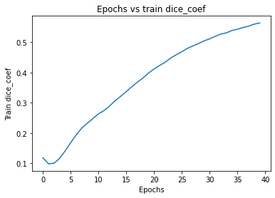

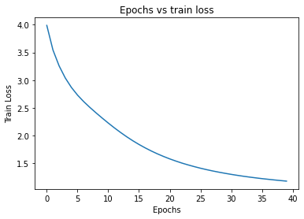

[figure not shown]

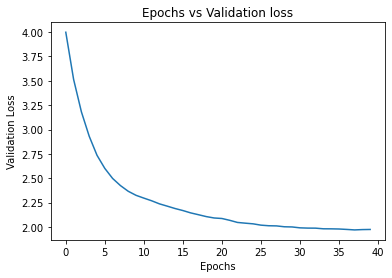

```python
from matplotlib import pyplot
# plot metrics
pyplot.plot(history.history['dice_coef'])
pyplot.title('Epochs vs train dice_coef')
pyplot.xlabel('Epochs')
pyplot.ylabel('Train dice_coef')
pyplot.show()

# plot metrics
pyplot.plot(history.history['loss'])
pyplot.title('Epochs vs train loss')
pyplot.xlabel('Epochs')
pyplot.ylabel('Train Loss')
pyplot.show()

# plot metrics
pyplot.plot(history.history['dice_coef'])
pyplot.title('Epochs vs validation dice_coef')
pyplot.xlabel('Epochs')
pyplot.ylabel('Validation dice_coef')
pyplot.show()

# plot metrics
pyplot.plot(history.history['val_loss'])
pyplot.title('Epochs vs Validation loss')
pyplot.xlabel('Epochs')
pyplot.ylabel('Validation Loss')
pyplot.show()
```